# Econometria 1 - Prática 2

Neylson Crepalde

## Exercício 1

```r
library(foreign)
library(magrittr)
library(lmtest)
# Multiple plot function
#
# ggplot objects can be passed in ..., or to plotlist (as a list of ggplot objects)
# - cols:   Number of columns in layout
# - layout: A matrix specifying the layout. If present, 'cols' is ignored.
#
# If the layout is something like matrix(c(1,2,3,3), nrow=2, byrow=TRUE),
# then plot 1 will go in the upper left, 2 will go in the upper right, and
# 3 will go all the way across the bottom.
#
multiplot <- function(..., plotlist=NULL, file, cols=1, layout=NULL) {
  library(grid)
  # Make a list from the ... arguments and plotlist
  plots <- c(list(...), plotlist)
  numPlots = length(plots)
  # If layout is NULL, then use 'cols' to determine layout
  if (is.null(layout)) {
    # Make the panel
    # ncol: Number of columns of plots
    # nrow: Number of rows needed, calculated from # of cols
    layout <- matrix(seq(1, cols * ceiling(numPlots/cols)),
                    ncol = cols, nrow = ceiling(numPlots/cols))
  }
 if (numPlots==1) {
    print(plots[[1]])
  } else {
    # Set up the page
    grid.newpage()
    pushViewport(viewport(layout = grid.layout(nrow(layout), ncol(layout))))
    # Make each plot, in the correct location
    for (i in 1:numPlots) {
      # Get the i,j matrix positions of the regions that contain this subplot
      matchidx <- as.data.frame(which(layout == i, arr.ind = TRUE))
      print(plots[[i]], vp = viewport(layout.pos.row = matchidx$row,
                                      layout.pos.col = matchidx$col))
    }
  }
}
setwd('~/Documentos/Neylson Crepalde/Doutorado/Econometria1/aula_pratica2')
eqsal = read.dta("eqsal3.dta")
investimento = read.dta("Investimento.dta")
```

## 1) Será que o coeficiente de educação representa o verdadeiro efeito da educação sobre os salários, independente do sexo?

1. Estime a equação de salários acima e verifique a importância do sexo na determinação dos salários;

```r
reg1 = lm(lsal~educ+idade+idade2+sexo+raca, data = eqsal)
summary(reg1)
```

```
Call:
lm(formula = lsal ~ educ + idade + idade2 + sexo + raca, data = eqsal)

Residuals:
    Min      1Q  Median      3Q     Max
-4.0341 -0.4089  0.0080  0.4116  2.7620

Coefficients:
              Estimate Std. Error t value Pr(>|t|)
(Intercept)  3.317e+00  1.707e-01  19.428  < 2e-16 ***
educ         1.290e-01  2.699e-03  47.810  < 2e-16 ***
idade        6.913e-02  8.316e-03   8.313  < 2e-16 ***
idade2      -6.348e-04  9.887e-05  -6.421 1.49e-10 ***
sexo         5.690e-01  2.118e-02  26.870  < 2e-16 ***
raca         1.915e-01  2.192e-02   8.735  < 2e-16 ***
---
Signif. codes:  0 ‘***’ 0.001 ‘**’ 0.01 ‘*’ 0.05 ‘.’ 0.1 ‘ ’ 1

Residual standard error: 0.7056 on 4526 degrees of freedom
Multiple R-squared:  0.4262,    Adjusted R-squared:  0.4255
F-statistic: 672.2 on 5 and 4526 DF,  p-value: < 2.2e-16
```

```r
cat('Exponencial do beta de sexo:\n');exp(reg1$coefficients[5])
```

```
Exponencial do beta de sexo:
    sexo
1.766545
```

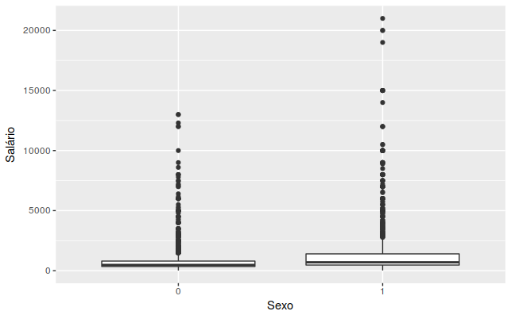

```r
library(ggplot2)
ggplot(eqsal, aes(x=factor(sexo), y=sal))+geom_boxplot()+labs(y='Salário',x='Sexo')
```

2. Agora estime a equação somente com as variáveis educ e sexo.

```r
reg3 = lm(lsal~educ+sexo, data=eqsal)
summary(reg3)
```

```
Call:
lm(formula = lsal ~ educ + sexo, data = eqsal)

Residuals:
    Min      1Q  Median      3Q     Max
-4.0681 -0.4516 -0.0051  0.4332  3.0378

Coefficients:
            Estimate Std. Error t value Pr(>|t|)
(Intercept) 5.092793   0.029409  173.17   <2e-16 ***
educ        0.127327   0.002656   47.94   <2e-16 ***
sexo        0.570462   0.022017   25.91   <2e-16 ***
---
Signif. codes:  0 ‘***’ 0.001 ‘**’ 0.01 ‘*’ 0.05 ‘.’ 0.1 ‘ ’ 1

Residual standard error: 0.7342 on 4529 degrees of freedom
Multiple R-squared:  0.3784,    Adjusted R-squared:  0.3781
F-statistic:  1379 on 2 and 4529 DF,  p-value: < 2.2e-16
```

```r
reg4 = lm(lsal~sexo, data = eqsal)
summary(reg4)
```

```
Call:
lm(formula = lsal ~ sexo, data = eqsal)

Residuals:
    Min      1Q  Median      3Q     Max
-3.7421 -0.5233 -0.1590  0.4770  3.2144

Coefficients:
            Estimate Std. Error t value Pr(>|t|)
(Intercept)  6.26820    0.01993  314.43   <2e-16 ***
sexo         0.46966    0.02691   17.46   <2e-16 ***
---
Signif. codes:  0 ‘***’ 0.001 ‘**’ 0.01 ‘*’ 0.05 ‘.’ 0.1 ‘ ’ 1

Residual standard error: 0.9013 on 4530 degrees of freedom
Multiple R-squared:  0.06303,   Adjusted R-squared:  0.06282
F-statistic: 304.7 on 1 and 4530 DF,  p-value: < 2.2e-16
```

```r
res_sal_com_educ = residuals(reg4)
```

4. Agora estime uma equação da variável educ sobre sexo e extraia os resíduos

```r
reg5 = lm(educ~sexo, data=eqsal)
summary(reg5)
```

```
Call:
lm(formula = educ ~ sexo, data = eqsal)

Residuals:
    Min      1Q  Median      3Q     Max
-9.2314 -3.4397  0.5603  2.5603  6.5603

Coefficients:
            Estimate Std. Error t value Pr(>|t|)
(Intercept)  9.23141    0.09083 101.628  < 2e-16 ***
sexo        -0.79170    0.12259  -6.458 1.17e-10 ***
---
Signif. codes:  0 ‘***’ 0.001 ‘**’ 0.01 ‘*’ 0.05 ‘.’ 0.1 ‘ ’ 1

Residual standard error: 4.107 on 4530 degrees of freedom
Multiple R-squared:  0.009122,  Adjusted R-squared:  0.008903
F-statistic:  41.7 on 1 and 4530 DF,  p-value: 1.174e-10
```

```r
res_sal_edu_sem_sexo = residuals(reg5)
```

5. Agora estime uma equação dos resíduos da primeira sobre os resíduos da segunda e interprete os resultados.

```r
reg6 = lm(res_sal_com_educ~res_sal_edu_sem_sexo)
summary(reg6)
```

```
Call:
lm(formula = res_sal_com_educ ~ res_sal_edu_sem_sexo)

Residuals:
    Min      1Q  Median      3Q     Max
-4.0681 -0.4516 -0.0051  0.4332  3.0378

Coefficients:
                       Estimate Std. Error t value Pr(>|t|)
(Intercept)          -2.391e-15  1.090e-02    0.00        1
res_sal_edu_sem_sexo  1.273e-01  2.656e-03   47.94   <2e-16 ***
---
Signif. codes:  0 ‘***’ 0.001 ‘**’ 0.01 ‘*’ 0.05 ‘.’ 0.1 ‘ ’ 1

Residual standard error: 0.7341 on 4530 degrees of freedom
Multiple R-squared:  0.3366,    Adjusted R-squared:  0.3365
F-statistic:  2299 on 1 and 4530 DF,  p-value: < 2.2e-16
```

```r
# O efeito estimado pela regressão particionada é igual ao efeito de educ no modelo original?
coef(reg6)[2]; coef(reg3)[2]
```

```
res_sal_edu_sem_sexo
           0.1273275
     educ
0.1273275
```

**Interpretação:** o resultado mostra que os efeitos estimados na primeira equação de salário controlando por sexo e educação são de fato isolados.

## Exercício 2

1. Declare os dados como de série temporal e faça um grafico das variáveis Inv_real e PNB_real Crie um termo de tendência deterministica e faça um gráfico das variáveis Inv_real e PNB_real em relação à essa tendência.

```r
library(ggplot2)
library(timeSeries)
# declarando como variáveis temporais
inv_real = ts(investimento$inv_real, start=1980, end = 1994)
pnb_real = ts(investimento$pnb_real, start=1980, end = 1994)
par(mfrow=c(2,1))
plot.ts(inv_real)
plot.ts(pnb_real)
```

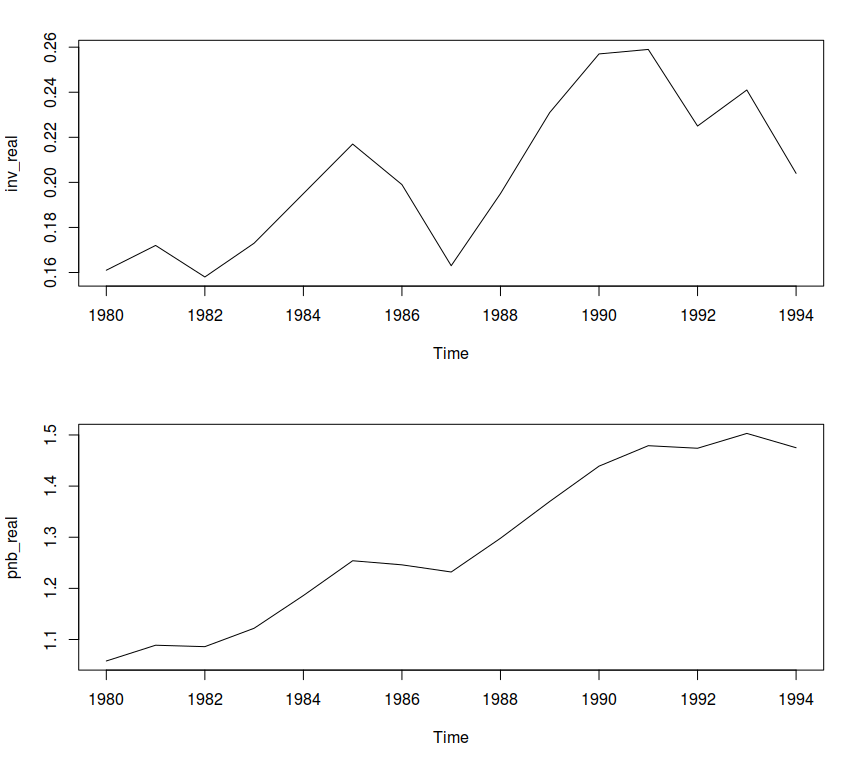

```r
par(mfrow=c(1,1))
```

2. Crie um termo de tendência deterministica e faça um gráfico das variáveis Inv_real e PNB_real em relação à essa tendência.

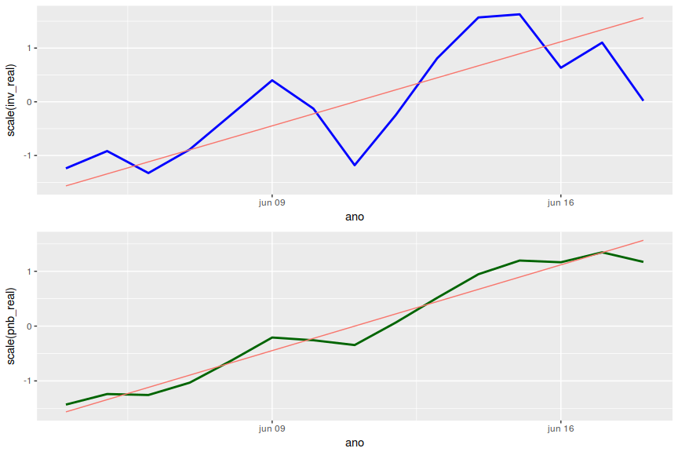

```r
investimento$tend = seq_along(inv_real)
investimento$ano %<>% as.Date
#Plotando um pouco mais elegante com ggplot2
g1 = ggplot(investimento, aes(x=ano))+geom_line(aes(y=scale(inv_real)), color = "blue", lwd=1)+geom_line(aes(y=scale(tend), color="red"))+theme(legend.position = 'none')
g2 = ggplot(investimento, aes(x=ano))+geom_line(aes(y=scale(pnb_real)), color = "darkgreen", lwd=1)+geom_line(aes(y=scale(tend), color="red"))+theme(legend.position = 'none')
multiplot(g1,g2, cols=1)
```

3. Estime equações de tendência para o inv_real e para o pnb_real e depois um modelo do inv_real sobre o pnb_real somente e incluindo um termo de tendência e compare os resultados.

```r
reg1 = lm(inv_real~tend, data=investimento)
summary(reg1)
```

```
Call:
lm(formula = inv_real ~ tend, data = investimento)

Residuals:
      Min        1Q    Median        3Q       Max
-0.040333 -0.010740  0.001395  0.012531  0.036481

Coefficients:
            Estimate Std. Error t value Pr(>|t|)
(Intercept) 0.157505   0.012756  12.348 1.48e-08 ***
tend        0.005729   0.001403   4.083  0.00129 **
---
Signif. codes:  0 ‘***’ 0.001 ‘**’ 0.01 ‘*’ 0.05 ‘.’ 0.1 ‘ ’ 1

Residual standard error: 0.02348 on 13 degrees of freedom
Multiple R-squared:  0.5619,    Adjusted R-squared:  0.5282
F-statistic: 16.67 on 1 and 13 DF,  p-value: 0.001293
```

```r
reg2 = lm(pnb_real~tend, data=investimento)
summary(reg2)
```

```
Call:
lm(formula = pnb_real ~ tend, data = investimento)

Residuals:
      Min        1Q    Median        3Q       Max
-0.057767 -0.024805  0.005288  0.014249  0.051396

Coefficients:
            Estimate Std. Error t value Pr(>|t|)
(Intercept) 1.006952   0.018596   54.15  < 2e-16 ***
tend        0.035054   0.002045   17.14 2.64e-10 ***
---
Signif. codes:  0 ‘***’ 0.001 ‘**’ 0.01 ‘*’ 0.05 ‘.’ 0.1 ‘ ’ 1

Residual standard error: 0.03422 on 13 degrees of freedom
Multiple R-squared:  0.9576,    Adjusted R-squared:  0.9544
F-statistic: 293.8 on 1 and 13 DF,  p-value: 2.637e-10
```

```r
reg3 = lm(inv_real~pnb_real, data=investimento)
summary(reg3)
```

```
Call:
lm(formula = inv_real ~ pnb_real, data = investimento)

Residuals:
      Min        1Q    Median        3Q       Max
-0.033886 -0.009266  0.000126  0.011395  0.025744

Coefficients:
            Estimate Std. Error t value Pr(>|t|)
(Intercept) -0.03377    0.03873  -0.872    0.399
pnb_real     0.18417    0.02987   6.166  3.4e-05 ***
---
Signif. codes:  0 ‘***’ 0.001 ‘**’ 0.01 ‘*’ 0.05 ‘.’ 0.1 ‘ ’ 1

Residual standard error: 0.0179 on 13 degrees of freedom
Multiple R-squared:  0.7452,    Adjusted R-squared:  0.7256
F-statistic: 38.03 on 1 and 13 DF,  p-value: 3.397e-05
```

```r
reg4 = lm(inv_real~tend+pnb_real, data=investimento)
summary(reg4)
```

```
Call:
lm(formula = inv_real ~ tend + pnb_real, data = investimento)

Residuals:
       Min         1Q     Median         3Q        Max
-0.0143836 -0.0029332  0.0003654  0.0058375  0.0090191

Coefficients:
             Estimate Std. Error t value Pr(>|t|)
(Intercept) -0.500135   0.061119  -8.183 2.98e-06 ***
tend        -0.017165   0.002169  -7.912 4.21e-06 ***
pnb_real     0.653099   0.060563  10.784 1.58e-07 ***
---
Signif. codes:  0 ‘***’ 0.001 ‘**’ 0.01 ‘*’ 0.05 ‘.’ 0.1 ‘ ’ 1

Residual standard error: 0.007473 on 12 degrees of freedom
Multiple R-squared:  0.959, Adjusted R-squared:  0.9522
F-statistic: 140.4 on 2 and 12 DF,  p-value: 4.736e-09
```

4. Compare também o modelo de regressão com todas as variáveis com e sem a tendência.

```r
reg1 = lm(inv_real~pnb_real+tx_juros+tx_infla, data=investimento)
summary(reg1)
```

```
Call:
lm(formula = inv_real ~ pnb_real + tx_juros + tx_infla, data = investimento)

Residuals:
      Min        1Q    Median        3Q       Max
-0.031185 -0.004879  0.003154  0.009146  0.020952

Coefficients:
              Estimate Std. Error t value Pr(>|t|)
(Intercept) -0.0728932  0.0503407  -1.448 0.175513
pnb_real     0.2366159  0.0514639   4.598 0.000768 ***
tx_juros    -0.0035661  0.0032771  -1.088 0.299787
tx_infla    -0.0002726  0.0036476  -0.075 0.941776
---
Signif. codes:  0 ‘***’ 0.001 ‘**’ 0.01 ‘*’ 0.05 ‘.’ 0.1 ‘ ’ 1

Residual standard error: 0.01818 on 11 degrees of freedom
Multiple R-squared:  0.7777,    Adjusted R-squared:  0.7171
F-statistic: 12.83 on 3 and 11 DF,  p-value: 0.0006503
```

```r
reg2 = lm(inv_real~pnb_real+tx_juros+tx_infla+tend, data=investimento)
summary(reg2)
```

```
Call:
lm(formula = inv_real ~ pnb_real + tx_juros + tx_infla + tend,
    data = investimento)

Residuals:
       Min         1Q     Median         3Q        Max
-0.0102670 -0.0025043  0.0004867  0.0030186  0.0081076

Coefficients:
              Estimate Std. Error t value Pr(>|t|)
(Intercept) -5.088e-01  5.519e-02  -9.219 3.33e-06 ***
pnb_real     6.700e-01  5.505e-02  12.171 2.56e-07 ***
tx_juros    -2.349e-03  1.221e-03  -1.924   0.0832 .
tx_infla    -8.411e-05  1.349e-03  -0.062   0.9515
tend        -1.655e-02  1.972e-03  -8.390 7.74e-06 ***
---
Signif. codes:  0 ‘***’ 0.001 ‘**’ 0.01 ‘*’ 0.05 ‘.’ 0.1 ‘ ’ 1

Residual standard error: 0.006724 on 10 degrees of freedom
Multiple R-squared:  0.9724,    Adjusted R-squared:  0.9613
F-statistic: 87.93 on 4 and 10 DF,  p-value: 9.466e-08
```

5. Comprove o teorema de **Frisch-Waugh-Lovell.** Questão a responder: será que é necessário extrair a tendência das variáveis antes de utilizá-las em um modelo de regressão?

```r
reg1 = lm(inv_real~tend, data = investimento)
e1 = residuals(reg1)
reg2 = lm(pnb_real~tend, data=investimento)
e2 = residuals(reg2)
reg3 = lm(e1~e2)
summary(reg3)
```

```
Call:
lm(formula = e1 ~ e2)

Residuals:
       Min         1Q     Median         3Q        Max
-0.0143836 -0.0029332  0.0003654  0.0058375  0.0090191

Coefficients:
             Estimate Std. Error t value Pr(>|t|)
(Intercept) 4.479e-19  1.854e-03    0.00        1
e2          6.531e-01  5.819e-02   11.22 4.64e-08 ***
---
Signif. codes:  0 ‘***’ 0.001 ‘**’ 0.01 ‘*’ 0.05 ‘.’ 0.1 ‘ ’ 1

Residual standard error: 0.00718 on 13 degrees of freedom
Multiple R-squared:  0.9065,    Adjusted R-squared:  0.8993
F-statistic:   126 on 1 and 13 DF,  p-value: 4.639e-08
```

```r
reg4 = lm(e1~0+e2)
summary(reg4)
```

```
Call:
lm(formula = e1 ~ 0 + e2)

Residuals:
       Min         1Q     Median         3Q        Max
-0.0143836 -0.0029332  0.0003654  0.0058375  0.0090191

Coefficients:
   Estimate Std. Error t value Pr(>|t|)
e2  0.65310    0.05607   11.65 1.37e-08 ***
---
Signif. codes:  0 ‘***’ 0.001 ‘**’ 0.01 ‘*’ 0.05 ‘.’ 0.1 ‘ ’ 1

Residual standard error: 0.006919 on 14 degrees of freedom
Multiple R-squared:  0.9065,    Adjusted R-squared:  0.8998
F-statistic: 135.7 on 1 and 14 DF,  p-value: 1.37e-08
```

```r
reg5 = lm(inv_real~pnb_real+tend, data=investimento)
summary(reg5)
```

```
Call:
lm(formula = inv_real ~ pnb_real + tend, data = investimento)

Residuals:
       Min         1Q     Median         3Q        Max
-0.0143836 -0.0029332  0.0003654  0.0058375  0.0090191

Coefficients:
             Estimate Std. Error t value Pr(>|t|)
(Intercept) -0.500135   0.061119  -8.183 2.98e-06 ***
pnb_real     0.653099   0.060563  10.784 1.58e-07 ***
tend        -0.017165   0.002169  -7.912 4.21e-06 ***
---
Signif. codes:  0 ‘***’ 0.001 ‘**’ 0.01 ‘*’ 0.05 ‘.’ 0.1 ‘ ’ 1

Residual standard error: 0.007473 on 12 degrees of freedom
Multiple R-squared:  0.959, Adjusted R-squared:  0.9522
F-statistic: 140.4 on 2 and 12 DF,  p-value: 4.736e-09
```